# Session 2: Tidyverse

> **Data manipulation and visualisation**

# 1 Tidyverse functionality

Tidyverse is a package, or a set of add-on tools, that you can optionally use in R to easily and clearly process and visualise your data. In the tidyverse, there are a number of included packages. You do not need to use them all, nor do you need to load them all, but for simplicity’s sake, it’s easier to load the whole thing and then not worry about it.

```r
## Packages required for this lesson:
#install.packages(c("knitr","tidyverse","cowplot"))
library(tidyverse) # Rstudio should prompt you if a package is required to run a notebook but isn't installed.
```

## 1.1 Quick recap

- `%>%` is called a “pipe”
- It passes the previous line into the data argument of the next line
- It does not save any changes after output

For our examples for now, we’ll use a built-in dataset called `quakes`.

Please take notes as we go along.

```r
# An example as a reminder
str(quakes) # base R code
```

```
'data.frame':   1000 obs. of  5 variables:
 $ lat     : num  -20.4 -20.6 -26 -18 -20.4 ...
 $ long    : num  182 181 184 182 182 ...
 $ depth   : int  562 650 42 626 649 195 82 194 211 622 ...
 $ mag     : num  4.8 4.2 5.4 4.1 4 4 4.8 4.4 4.7 4.3 ...
 $ stations: int  41 15 43 19 11 12 43 15 35 19 ...
```

```r
quakes %>% str() # tidy R code
```

```
'data.frame':   1000 obs. of  5 variables:
 $ lat     : num  -20.4 -20.6 -26 -18 -20.4 ...
 $ long    : num  182 181 184 182 182 ...
 $ depth   : int  562 650 42 626 649 195 82 194 211 622 ...
 $ mag     : num  4.8 4.2 5.4 4.1 4 4 4.8 4.4 4.7 4.3 ...
 $ stations: int  41 15 43 19 11 12 43 15 35 19 ...
```

How would you write the base R function `head(quakes)` using `tidyverse`?

```r
# Check it here, then type your answer into the chat!
quakes %>% head()
```

|  | lat | long | depth | mag | stations |
| --- | --- | --- | --- | --- | --- |
| 1 | -20.42 | 181.62 | 562 | 4.8 | 41 |
| 2 | -20.62 | 181.03 | 650 | 4.2 | 15 |
| 3 | -26.00 | 184.10 | 42 | 5.4 | 43 |
| 4 | -17.97 | 181.66 | 626 | 4.1 | 19 |
| 5 | -20.42 | 181.96 | 649 | 4.0 | 11 |
| 6 | -19.68 | 184.31 | 195 | 4.0 | 12 |

The verb `count()` counts how many attestations there are of each level in the specified column.

How many attestations of each type of `mag` in `quakes`?

```r
# using `count()`
quakes %>% count(mag)
```

| mag | n |
| --- | --- |
| 4.0 | 46 |
| 4.1 | 55 |
| 4.2 | 90 |
| 4.3 | 85 |
| 4.4 | 101 |
| 4.5 | 107 |
| 4.6 | 101 |
| 4.7 | 98 |
| 4.8 | 65 |
| 4.9 | 54 |

[output cut: 12 more lines]

# 2 Processing data

Before we start learning anything about the shape of our data and statistical results, we often need to process and organise the data.

## 2.1 Filter

If we only want to look at magnitudes between 4.5 and 4.9 from `quakes`, we can filter the dataset (which is like subsetting):

```r
# recap from last session
quakes %>%
  filter(mag > 4.5 & mag < 4.9)
```

| lat | long | depth | mag | stations |
| --- | --- | --- | --- | --- |
| -20.42 | 181.62 | 562 | 4.8 | 41 |
| -11.70 | 166.10 | 82 | 4.8 | 43 |
| -28.74 | 181.74 | 211 | 4.7 | 35 |
| -12.26 | 167.00 | 249 | 4.6 | 16 |
| -30.20 | 182.00 | 125 | 4.7 | 22 |
| -14.72 | 167.51 | 155 | 4.6 | 18 |
| -22.58 | 179.24 | 553 | 4.6 | 21 |
| -16.32 | 166.74 | 50 | 4.7 | 30 |
| -15.55 | 185.05 | 292 | 4.8 | 42 |
| -17.64 | 181.28 | 574 | 4.6 | 17 |

[output cut: 254 more lines]

## 2.2 Add columns

How can you make a new column?

```r
# DON'T DO THIS:
# quakes$newCol <- quakes$mag

# `mutate` just means "create"
quakes %>%
  mutate(newCol = NA)
```

| lat | long | depth | mag | stations | newCol |
| --- | --- | --- | --- | --- | --- |
| -20.42 | 181.62 | 562 | 4.8 | 41 | NA |
| -20.62 | 181.03 | 650 | 4.2 | 15 | NA |
| -26.00 | 184.10 | 42 | 5.4 | 43 | NA |
| -17.97 | 181.66 | 626 | 4.1 | 19 | NA |
| -20.42 | 181.96 | 649 | 4.0 | 11 | NA |
| -19.68 | 184.31 | 195 | 4.0 | 12 | NA |
| -11.70 | 166.10 | 82 | 4.8 | 43 | NA |
| -28.11 | 181.93 | 194 | 4.4 | 15 | NA |
| -28.74 | 181.74 | 211 | 4.7 | 35 | NA |
| -17.47 | 179.59 | 622 | 4.3 | 19 | NA |

[output cut: 990 more lines]

Duplicate `mag` into `magFct` for `quakes`:

```r
# `mutate`
quakes %>%
  mutate(magFct = as.factor(mag))
```

| lat | long | depth | mag | stations | magFct |
| --- | --- | --- | --- | --- | --- |
| -20.42 | 181.62 | 562 | 4.8 | 41 | 4.8 |
| -20.62 | 181.03 | 650 | 4.2 | 15 | 4.2 |
| -26.00 | 184.10 | 42 | 5.4 | 43 | 5.4 |
| -17.97 | 181.66 | 626 | 4.1 | 19 | 4.1 |
| -20.42 | 181.96 | 649 | 4.0 | 11 | 4 |
| -19.68 | 184.31 | 195 | 4.0 | 12 | 4 |
| -11.70 | 166.10 | 82 | 4.8 | 43 | 4.8 |
| -28.11 | 181.93 | 194 | 4.4 | 15 | 4.4 |
| -28.74 | 181.74 | 211 | 4.7 | 35 | 4.7 |
| -17.47 | 179.59 | 622 | 4.3 | 19 | 4.3 |

[output cut: 990 more lines]

Create a column in `quakes` that calculates the `depth` of the quake divided by the number of `stations` reporting:

```r
# `mutate`
quakes %>%
  mutate(depBySta = depth/stations)
```

| lat | long | depth | mag | stations | depBySta |
| --- | --- | --- | --- | --- | --- |
| -20.42 | 181.62 | 562 | 4.8 | 41 | 13.7073171 |
| -20.62 | 181.03 | 650 | 4.2 | 15 | 43.3333333 |
| -26.00 | 184.10 | 42 | 5.4 | 43 | 0.9767442 |
| -17.97 | 181.66 | 626 | 4.1 | 19 | 32.9473684 |
| -20.42 | 181.96 | 649 | 4.0 | 11 | 59.0000000 |
| -19.68 | 184.31 | 195 | 4.0 | 12 | 16.2500000 |
| -11.70 | 166.10 | 82 | 4.8 | 43 | 1.9069767 |
| -28.11 | 181.93 | 194 | 4.4 | 15 | 12.9333333 |
| -28.74 | 181.74 | 211 | 4.7 | 35 | 6.0285714 |
| -17.47 | 179.59 | 622 | 4.3 | 19 | 32.7368421 |

[output cut: 990 more lines]

## 2.3 Logical operators

These will be useful throughout your work in R, but also pretty much any other programming language you encounter:

- `==` equivalent to
- `>` greater than
- `<` less than
- `>=` greater than or equal to
- `<=` less than or equal to
- `!=` NOT equivalent to (“bang-equals”)
- `&` and
- `|` or

## 2.4 Case when

Tidyverse tries to reduce the need for “for loops”. Instead of going line by line through a dataset to determine what contingent behaviour to perform, `case_when` simplifies this. The for-loop behaviour is time and energy intensive on large datasets. That’s why `case_when` is so simple and yet so powerful.

Here’s an example of how one might create a column that translates the values in `mag` in `quakes` to a word:

```r
quakes %>% #
  mutate(magText = case_when(mag <  5 ~ "four",
                             mag >= 6 ~ "six",
                             TRUE ~ "five"))
```

| lat | long | depth | mag | stations | magText |
| --- | --- | --- | --- | --- | --- |
| -20.42 | 181.62 | 562 | 4.8 | 41 | four |
| -20.62 | 181.03 | 650 | 4.2 | 15 | four |
| -26.00 | 184.10 | 42 | 5.4 | 43 | five |
| -17.97 | 181.66 | 626 | 4.1 | 19 | four |
| -20.42 | 181.96 | 649 | 4.0 | 11 | four |
| -19.68 | 184.31 | 195 | 4.0 | 12 | four |
| -11.70 | 166.10 | 82 | 4.8 | 43 | four |
| -28.11 | 181.93 | 194 | 4.4 | 15 | four |
| -28.74 | 181.74 | 211 | 4.7 | 35 | four |
| -17.47 | 179.59 | 622 | 4.3 | 19 | four |

[output cut: 990 more lines]

Now, how would you create a column in `quakes` that groups magnitude into “low”, “medium” and “high”? What if we want a fourth category?

```r
# `mutate` and `case_when`
quakes %>%
  mutate(magGroups = case_when(mag <= 4.8 & mag > 4.4 ~ "low",
                               mag > 4.8 & mag <= 5.4 ~ "medium",
                               mag > 5.4 ~ "high",
                               TRUE ~ "other"))
```

| lat | long | depth | mag | stations | magGroups |
| --- | --- | --- | --- | --- | --- |
| -20.42 | 181.62 | 562 | 4.8 | 41 | low |
| -20.62 | 181.03 | 650 | 4.2 | 15 | other |
| -26.00 | 184.10 | 42 | 5.4 | 43 | medium |
| -17.97 | 181.66 | 626 | 4.1 | 19 | other |
| -20.42 | 181.96 | 649 | 4.0 | 11 | other |
| -19.68 | 184.31 | 195 | 4.0 | 12 | other |
| -11.70 | 166.10 | 82 | 4.8 | 43 | low |
| -28.11 | 181.93 | 194 | 4.4 | 15 | other |
| -28.74 | 181.74 | 211 | 4.7 | 35 | low |
| -17.47 | 179.59 | 622 | 4.3 | 19 | other |

[output cut: 990 more lines]

We can also use this to perform other sorts of contingent calculations.

Create a column that adds 10 to `long` when it is above 175 and subtracts 10 from `long` when it is below 175:

```r
# take 5 minutes to fill in the ??? with values to accomplish the task
quakes %>%
  mutate(longEdit = case_when(long > 175 ~ long+10,
                          long < 175 ~ long-10))
```

| lat | long | depth | mag | stations | longEdit |
| --- | --- | --- | --- | --- | --- |
| -20.42 | 181.62 | 562 | 4.8 | 41 | 191.62 |
| -20.62 | 181.03 | 650 | 4.2 | 15 | 191.03 |
| -26.00 | 184.10 | 42 | 5.4 | 43 | 194.10 |
| -17.97 | 181.66 | 626 | 4.1 | 19 | 191.66 |
| -20.42 | 181.96 | 649 | 4.0 | 11 | 191.96 |
| -19.68 | 184.31 | 195 | 4.0 | 12 | 194.31 |
| -11.70 | 166.10 | 82 | 4.8 | 43 | 156.10 |
| -28.11 | 181.93 | 194 | 4.4 | 15 | 191.93 |
| -28.74 | 181.74 | 211 | 4.7 | 35 | 191.74 |
| -17.47 | 179.59 | 622 | 4.3 | 19 | 189.59 |

[output cut: 990 more lines]

## 2.5 Group and summarise

What if we want to get aggregate values from our dataset, rather than looking at it as a whole?

**`group_by`** is a verb that flags certain columns for operations down the line. **`summarise`** checks which columns are flagged and performs operations based on the permuations of values in those columns.

What happens when we use `group_by` by itself?

```r
# look at each step of the code by itself to understand what it is doing
quakes %>%
  group_by(mag)
```

| lat | long | depth | mag | stations |
| --- | --- | --- | --- | --- |
| -20.42 | 181.62 | 562 | 4.8 | 41 |
| -20.62 | 181.03 | 650 | 4.2 | 15 |
| -26.00 | 184.10 | 42 | 5.4 | 43 |
| -17.97 | 181.66 | 626 | 4.1 | 19 |
| -20.42 | 181.96 | 649 | 4.0 | 11 |
| -19.68 | 184.31 | 195 | 4.0 | 12 |
| -11.70 | 166.10 | 82 | 4.8 | 43 |
| -28.11 | 181.93 | 194 | 4.4 | 15 |
| -28.74 | 181.74 | 211 | 4.7 | 35 |
| -17.47 | 179.59 | 622 | 4.3 | 19 |

[output cut: 990 more lines]

How many observations are there per “level” of magnitude?

```r
# using `summarise()`
quakes %>%
  group_by(mag) %>%
  summarise(numberOfQuakes = n())
```

| mag | numberOfQuakes |
| --- | --- |
| 4.0 | 46 |
| 4.1 | 55 |
| 4.2 | 90 |
| 4.3 | 85 |
| 4.4 | 101 |
| 4.5 | 107 |
| 4.6 | 101 |
| 4.7 | 98 |
| 4.8 | 65 |
| 4.9 | 54 |

[output cut: 12 more lines]

We can use `group_by` and `summarise` to do a lot more than just count:

```r
# mean value of `stations` for `groupMag` magnitudes
quakes %>%
  mutate(groupMag = case_when(mag <= 4.8 ~ "low",
                              mag > 4.8 & mag <= 5.4 ~ "medium",
                              TRUE ~ "high") %>%
           recode_factor(`low`="low",
                         `medium`="medium",
                         `high`="high")) %>% # this turns our character vector into an ordered factor
  group_by(groupMag) %>%
  summarise(meanStations = mean(stations))
```

| groupMag | meanStations |
| --- | --- |
| low | 23.95455 |
| medium | 55.37383 |
| high | 96.05263 |

Let’s create a table of the means, standard deviations, and standard errors for both stations reporting and depths grouped by magnitude:

```r
# print a table of means, SDs and SEs
quakes %>%
  mutate(groupMag = case_when(mag <= 4.8 ~ "low",
                              mag > 4.8 & mag <= 5.4 ~ "medium",
                              TRUE ~ "high")) %>% # this turns our character vector into an ordered factor
  group_by(groupMag) %>%
  summarise(numberOfStations = n(),
            meanStations = mean(stations),
            sdStations = sd(stations),
            seStations = sdStations/sqrt(numberOfStations))
```

| groupMag | numberOfStations | meanStations | sdStations | seStations |
| --- | --- | --- | --- | --- |
| high | 38 | 96.05263 | 18.72265 | 3.0372152 |
| low | 748 | 23.95455 | 10.09383 | 0.3690671 |
| medium | 214 | 55.37383 | 18.23710 | 1.2466628 |

(This is VERY useful for graphing and creating summary statistics tables!)

## 2.6 Join and reshape

One type of data processing that can be a huge hassle without a programming language is merging or joining datasets.

In order to illustrate this, I will create two small datasets that imitate a survey.

Here is the demographic data:

```r
participant <- c("John", "Simone", "Aaliyah", "Marcus")
gender <- c("m", "f", "f", "m")
age <- c(24, 18, 38, NA)

demographics <- tibble(participant, gender, age)
```

Here is some quantitative survey data that also has some more qualitative responses:

```r
q1 <- c("yes", "yes", "yes", "no")
q2 <- c(4, 3, 4, 5)
q3 <- c(1, 4, 5, 2)
q4 <- c("rarely", "often", "always", "sometimes")
q5 <- c(1, 2, 1, 1)
q6 <- c(3, 1, 5, 5)

survey <- tibble(participant, q1, q2, q3, q4, q5, q6)
```

Combine the two datasets using the column they have in common:

```r
# save it as `mySurvey`
mySurvey <- full_join(demographics,survey, by = "participant")
```

Switch the rows and columns for only numeric survey questions:

```r
# save it as `mySurvey_long` with two new columns: `questions` and `responses`
mySurvey %>%
  pivot_longer(cols = c("q2","q3","q5","q6"),
               names_to = "questions",
               values_to = "responses") -> mySurvey_long
# look up `pivot_wider` for the function to reverse this
```

Why would you want to do this? It’s not as easy for human eyes to read, but it’s much easier to graph…

# 3 Visualisation

In the `tidyverse`, the package for making elegant plots is called `ggplot2`. It works a lot like how pipes work, but since it was originally designed as a separate package, it uses `+` instead of `%>%`.

To begin, we need to specify what data we’re using.

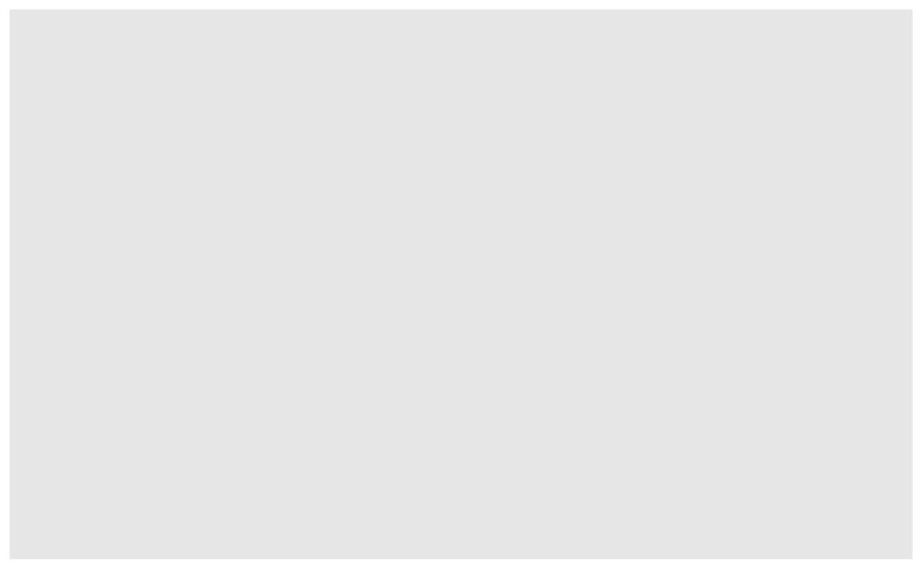

```r
# this will print a blank plot
mySurvey_long %>%
  ggplot()
```

Now we have to tell it what the axes are. Make the x-axis `participant` and the y-axis `responses`.

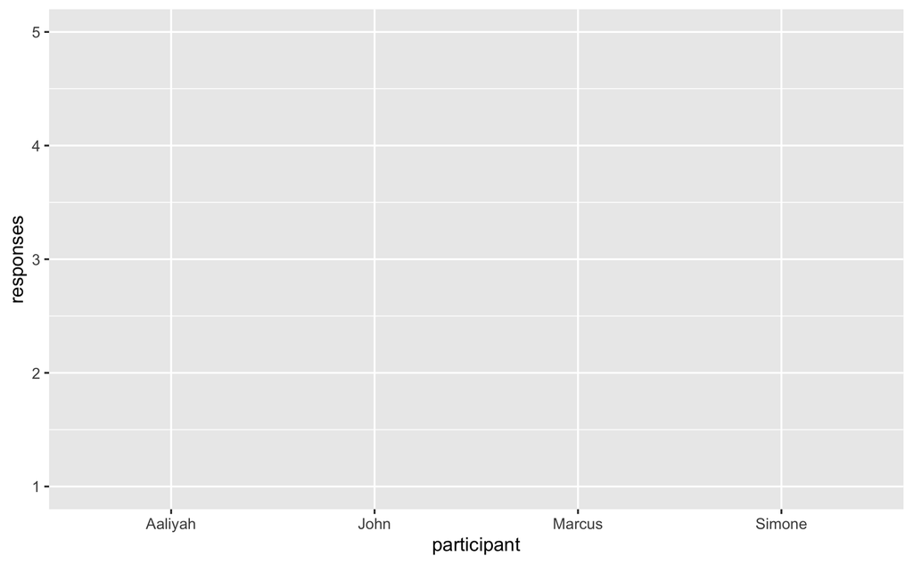

```r
# this will print a *mostly* blank plot...
mySurvey_long %>%
  ggplot(aes(x=participant, y= responses))
```

What’s the difference? Why isn’t the data visible?

Now let’s tell it what kind of plot to make. This is called the plot’s “geometry”, abbreviated “geom”.

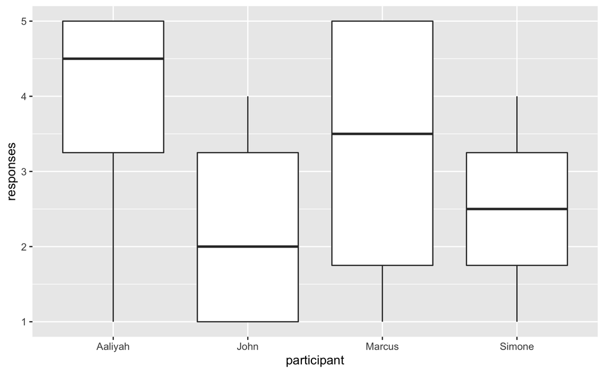

```r
# make a box and whisker plot
mySurvey_long %>%
  ggplot(aes(x=participant, y= responses)) +
  geom_boxplot()
```

We can add colours automatically to add more information to the plot

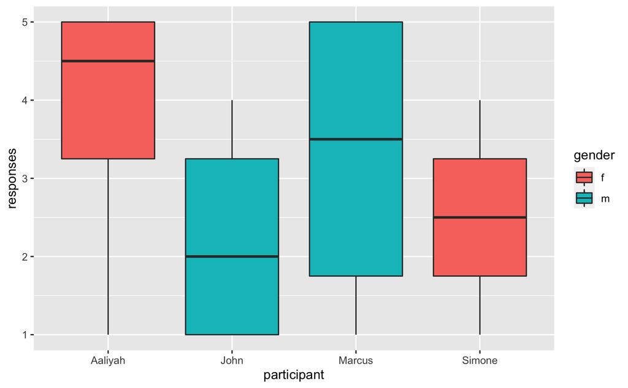

```r
# fill in plot with colour contigent on gender
mySurvey_long %>%
  ggplot(aes(x=participant, y= responses)) +
  geom_boxplot(aes(fill=gender))
```

Or maybe:

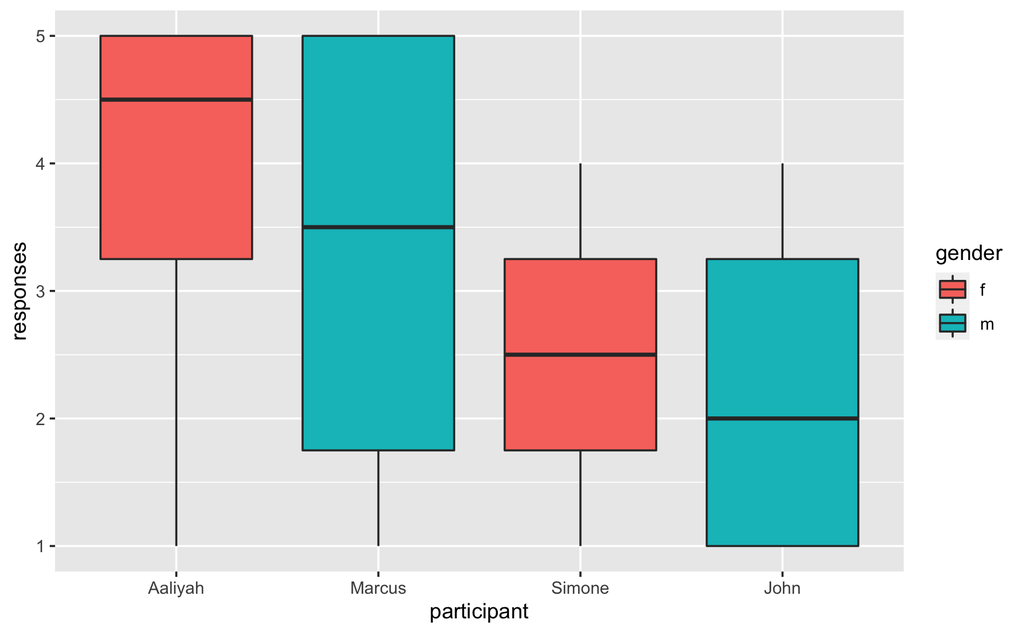

```r
# mutate(participant = fct_reorder(participant, desc(responses)))
mySurvey_long %>%
  mutate(participant = fct_reorder(participant, desc(responses))) %>%
  ggplot(aes(x=participant, y= responses)) +
  geom_boxplot(aes(fill=gender))
```

## 3.1 Arrange plots

To do this, we can use the library called `cowplot`.

```r
library(cowplot)
```

`cowplot` allows us to put multiple graphs into one window. You could do this by hand, too, but why not make it easy on yourself?

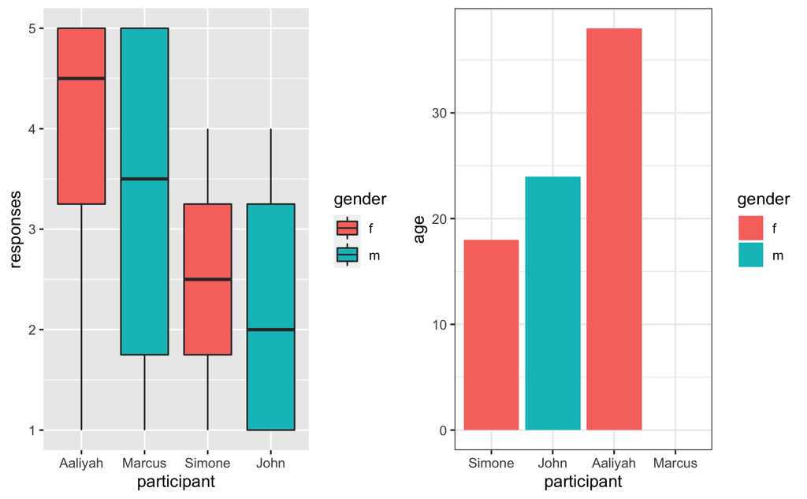

```r
# save the plot from before as 'p1' or any other variable name
mySurvey_long %>%
  mutate(participant = fct_reorder(participant, desc(responses))) %>%
  ggplot(aes(x=participant, y= responses)) +
  geom_boxplot(aes(fill=gender)) -> p1

# save another plot as 'p2'
mySurvey %>%
  mutate(participant = fct_reorder(participant,
                                   age)) %>%
  ggplot(aes(x = participant, y = age, fill=gender)) +
  geom_bar(stat = "identity") +
  theme_bw() -> p2

# plot them side by side
plot_grid(p1,p2)
```

# 4 Challenge activities

Work on these challenges on your own or in small groups this afternoon and we will go over possible solutions together at 16:00.

## 4.1 Exercise 1

Plot where earthquakes occur using latitude and longitude columns in `quakes`.

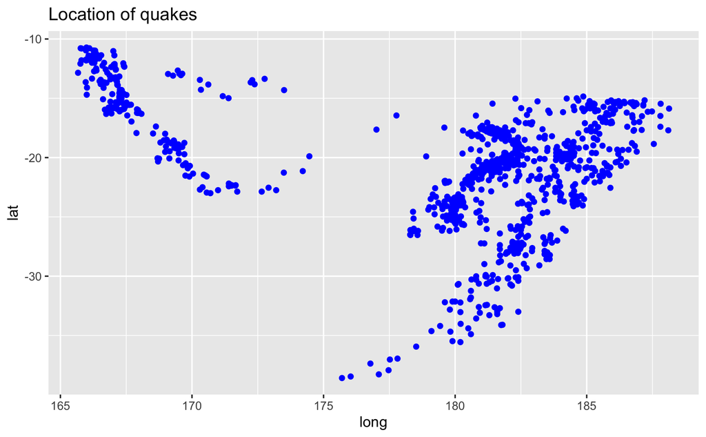

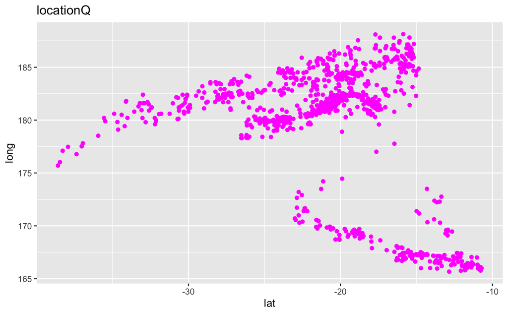

```r
# use this line of code at the end of your code to choose the two colours you use
# scale_colour_manual(values=c("red", "blue"))
# from Liangxun:
quakes %>%
  ggplot(aes(x = lat)) +
  geom_point(aes(y = long
                 ),
                 color = "magenta"
             )+
  ggtitle("locationQ") +
  scale_colour_manual(values=c("red", "blue"))
```

## 4.2 Exercise 2

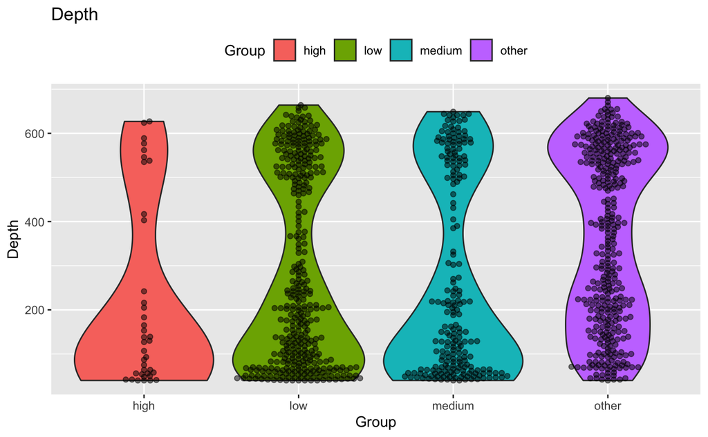

## 4.3 Exercise 3

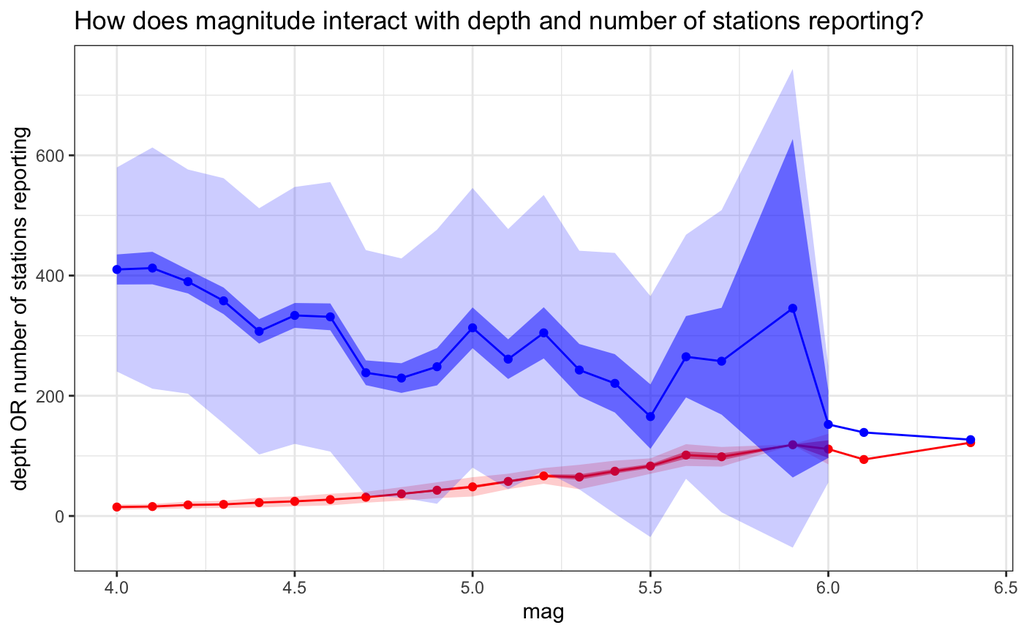

# 5 Further resources

1. [R for Data Science (R4DS)](https://r4ds.had.co.nz/) is a free book about using R and `tidyverse` to do all types of data science.
   - [Data transformation chapter](https://r4ds.had.co.nz/transform.html)
   - [Data visualisation chapter](https://r4ds.had.co.nz/data-visualisation.html)
2. [ggplot2: Elegant Graphics for Data Analysis](https://ggplot2-book.org/) is a free book about using `ggplot2` to create concise, informative, and beautiful graphics to communicate your data easily.
3. [Dataviz Cheatsheet PDF](https://github.com/rstudio/cheatsheets/blob/master/data-visualization-2.1.pdf)
4. [Data Wrangling Cheatsheet PDF](https://rstudio.com/wp-content/uploads/2015/02/data-wrangling-cheatsheet.pdf)
5. [Cowplot documentation](https://www.rdocumentation.org/packages/cowplot/versions/1.0.0/topics/plot_grid)